Given data and a model design, the computer will find the model function and model values for you. As an example, consider the Current Population Survey data `mosaicData::CPS85`. Suppose you want to build a model with `wage` as a response variable and `age` and `sex` as explanatory variables incorporated as main terms. Also include the intercept term, as usual.

Using the model design language, this model is `wage` ~ 1 + `age` + `sex`.

Use the `lm` operator to find the model function:

```r
mod1 <- lm( wage ~ 1 + age + sex, data = CPS85)
```

The two arguments to `lm()` are:

1. the model design, expressed as a formula: `wage` ~ 1 + `age` + `sex`.
2. the data to be used: `data = CPS85`

The `mod1 <-`… part of the command simply gives the model a name so that you can use it later on. If you construct more than one model, it makes sense to give them different names. But don’t re-use the name of the data frame; a name can be used for only one thing at a time.

In making a graph of the function, the model values will always be plotted on the vertical axis. But you have a choice of what to put on the horizontal axis. This plot puts the quantitative variable `age` on the x-axis, and uses color for `sex`.

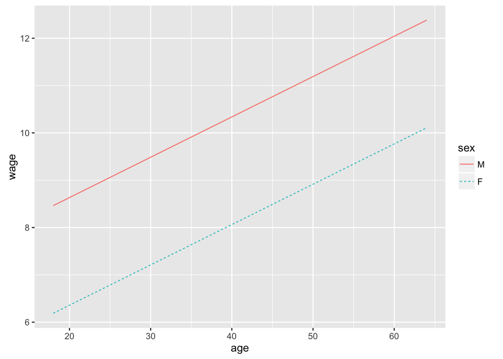

```r
fmodel(mod1, ~ age + sex)
```

You could arrange things the other way as well.

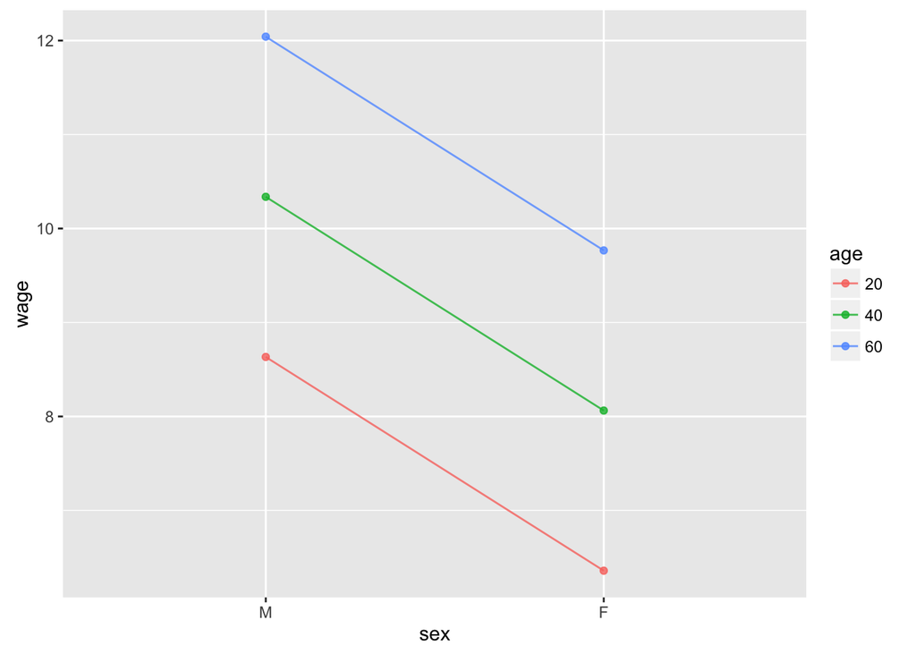

```r
fmodel(mod1, ~ sex + age)
```

Note that the line in this plot is merely to guide the eye. The `sex` variable is categorical and so it’s meaningless to interpolate between values.